# Statistical Inference Course Project - Part 2

Roshan Riazi

## Overview

Now in the second portion of the class, we’re going to analyze the ToothGrowth data in the R datasets package. So first we read the help page for ToothGrowth data and then we will perform the 4 specified steps.

## ToothGrowth Data Description

The response is the length of odontoblasts (teeth) in each of 10 guinea pigs at each of three dose levels of Vitamin C (0.5, 1, and 2 mg) with each of two delivery methods (orange juice or ascorbic acid).

## Step 1

In step 1, we should load the ToothGrowth data and perform some basic exploratory data analyses.

First we load ToothGrowth dataset:

```r
library(datasets)
data(ToothGrowth)
```

Then we can look at its first few rows, last few rows and its structure.

```r
head(ToothGrowth)
```

```
##    len supp dose
## 1  4.2   VC  0.5
## 2 11.5   VC  0.5
## 3  7.3   VC  0.5
## 4  5.8   VC  0.5
## 5  6.4   VC  0.5
## 6 10.0   VC  0.5
```

```r
tail(ToothGrowth)
```

```
##     len supp dose
## 55 24.8   OJ    2
## 56 30.9   OJ    2
## 57 26.4   OJ    2
## 58 27.3   OJ    2
## 59 29.4   OJ    2
## 60 23.0   OJ    2
```

```r
str(ToothGrowth)
```

```
## 'data.frame':    60 obs. of  3 variables:
##  $ len : num  4.2 11.5 7.3 5.8 6.4 10 11.2 11.2 5.2 7 ...
##  $ supp: Factor w/ 2 levels "OJ","VC": 2 2 2 2 2 2 2 2 2 2 ...
##  $ dose: num  0.5 0.5 0.5 0.5 0.5 0.5 0.5 0.5 0.5 0.5 ...
```

We can also look at a plot of length versus dose, color coded with supplements.

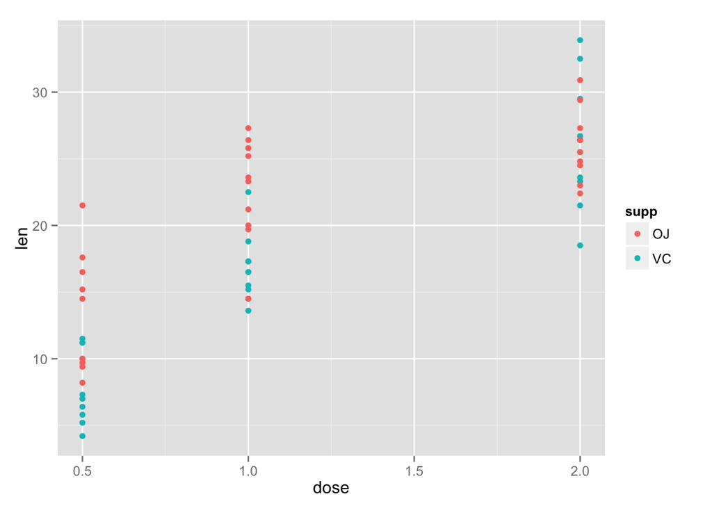

```r
library(ggplot2)
qplot(dose, len, data = ToothGrowth, color = supp)
```

There seems to be a relationship between dose and length, and some relationships between supplement and length for dose equal to 0.5 and 1. So we make a baxplot to better see the effect of dose and supplement on length of tooth:

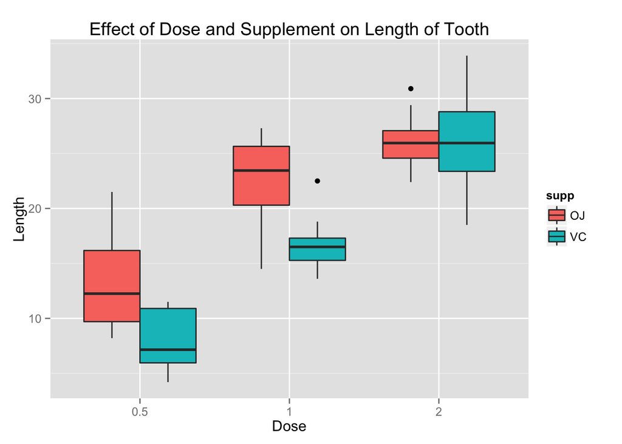

```r
plot2 <- ggplot(ToothGrowth, aes(x = as.factor(dose), y = len, fill = supp))
plot2 <- plot2 + geom_boxplot()
plot2 <- plot2 + labs(title = "Effect of Dose and Supplement on Length of Tooth", x = "Dose", y = "Length")
plot2
```

## Step 2

In step 2, we should provide a basic summary of the data.

We will look at its summary, and then calculate length’s mean and standard deviation for the whole dataset to get a feel of its properties.

```r
summary(ToothGrowth)
```

```
##       len        supp         dose
##  Min.   : 4.20   OJ:30   Min.   :0.500
##  1st Qu.:13.07   VC:30   1st Qu.:0.500
##  Median :19.25           Median :1.000
##  Mean   :18.81           Mean   :1.167
##  3rd Qu.:25.27           3rd Qu.:2.000
##  Max.   :33.90           Max.   :2.000
```

```r
mean(ToothGrowth$len)
```

```
## [1] 18.81333
```

```r
sd(ToothGrowth$len)
```

```
## [1] 7.649315
```

Next we loot at a table of supplements and dose:

```r
table(ToothGrowth$supp, ToothGrowth$dose)
```

```
##
##      0.5  1  2
##   OJ  10 10 10
##   VC  10 10 10
```

By looking at a this table, we can make sure that there are 10 observations for each combination. This confirms the description that there are 10 guinea pigs and in this experiment, each pig takes combinations of supplements with different dosage. (This is a paired experiment!)

We can plot the seperate effect of dose on length, and the seperate effect supplement on length.

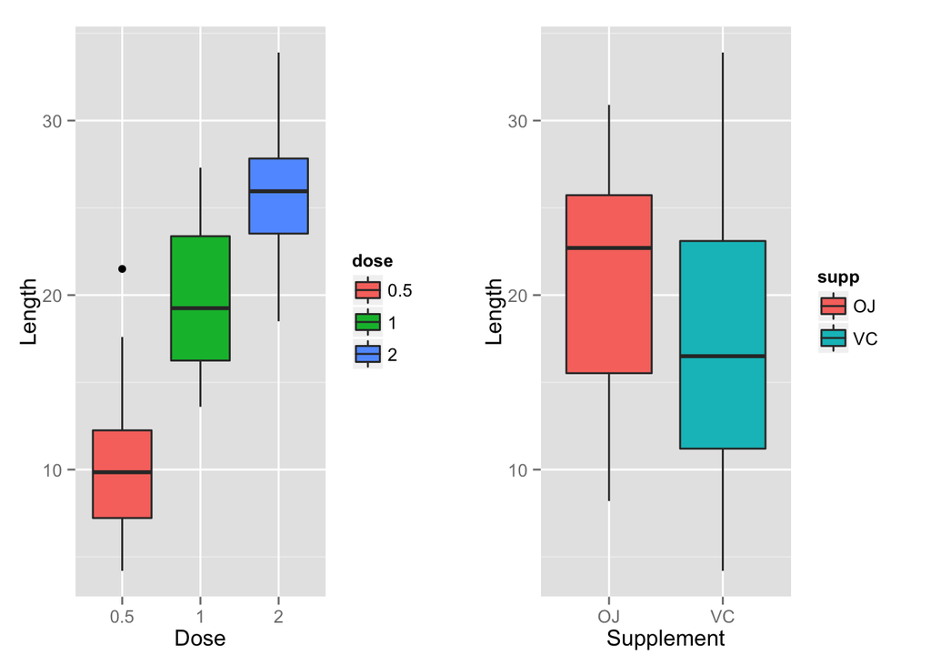

```r
suppressMessages(library(gridExtra))
plot2.1 <- ggplot(ToothGrowth, aes(x = as.factor(dose), y = len, fill = dose))
plot2.1 <- plot2.1 + geom_boxplot(aes(fill = as.factor(dose)))
plot2.1 <- plot2.1 + labs(x = "Dose", y = "Length")
plot2.2 <- ggplot(ToothGrowth, aes(x = supp, y = len, fill = supp))
plot2.2 <- plot2.2 + geom_boxplot(aes(fill = supp))
plot2.2 <- plot2.2 + labs(x = "Supplement", y = "Length")
grid.arrange(plot2.1, plot2.2, ncol = 2)
```

As this plot shows the seperate effect of dose and supplement on length, it will help us in making hypothesis for step 3.

```r
suppressMessages(library(dplyr))
filter(ToothGrowth, dose == 0.5) %>% summarise(dose0.5Mean = mean(len))
```

```
##   dose0.5Mean
## 1      10.605
```

```r
filter(ToothGrowth, dose == 1) %>% summarise(dose1Mean = mean(len))
```

```
##   dose1Mean
## 1    19.735
```

```r
filter(ToothGrowth, dose == 2) %>% summarise(dose2Mean = mean(len))
```

```
##   dose2Mean
## 1      26.1
```

```r
filter(ToothGrowth, supp == "OJ") %>% summarise(OJMean = mean(len))
```

```
##     OJMean
## 1 20.66333
```

```r
filter(ToothGrowth, supp == "VC") %>% summarise(VCMean = mean(len))
```

```
##     VCMean
## 1 16.96333
```